# Crash-course in hypothesis testing

27 March 2021

## About

This lecture accompanies the [Imaging Statistics](https://ilias.unibe.ch/goto_ilias3_unibe_crs_2077609.html) course given at the University of Bern as part of the [Microscopy Imaging Center](https://www.mic.unibe.ch) trainings.

Based on the [Minitab Blog](https://blog.minitab.com/en/adventures-in-statistics-2/understanding-hypothesis-tests-why-we-need-to-use-hypothesis-tests-in-statistics) series.

Other resources:

- [Comprehensive Confidence Intervals for Python Developers](https://aegis4048.github.io/comprehensive_confidence_intervals_for_python_developers#population_vs_samples)
- [Using t-tests in R](https://statistics.berkeley.edu/computing/r-t-tests)
- [Everything You Need To Know about Hypothesis Testing](https://towardsdatascience.com/everything-you-need-to-know-about-hypothesis-testing-part-i-4de9abebbc8a)

## Why We Need Hypothesis Tests?

> A hypothesis test evaluates two mutually exclusive statements about a **population** to determine which statement is best supported by the **sample** data.
- What does statistical significance mean?
- What is a p-value?
- How to interpret confidence intervals?

## Population vs Sample

How well a sample statistic estimates an underlying population parameter?

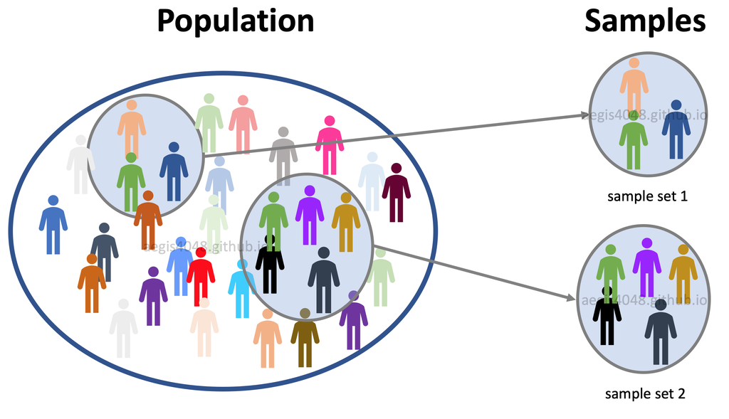

## Population

- Let’s measure the mean fluorescence intensity (FI) of cells subject to a treatment.
- The FI in single cells varies across the population and follows a distribution with \(\mu = 5\) (mean).

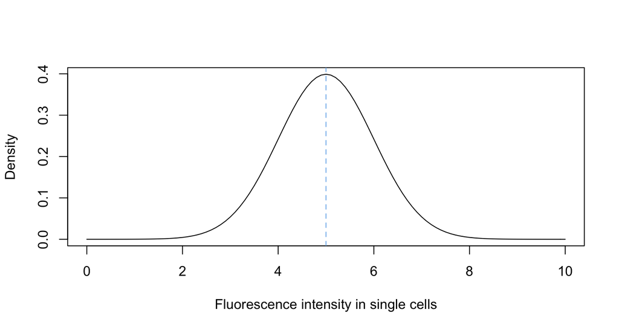

## Sample

- We’re interested in estimating the mean FI in the cell **population**.
- In experiments we cannot *access* the true population mean unless we measure everything.
- *Sampling* the reality is the next best thing we can do!
- A sample consists of measurements of FI in individual cells.
- A sample mean is the mean calculated from a sample.

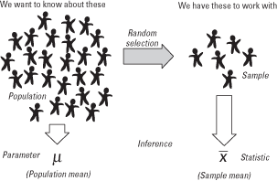

## Sample vs population statistic

- | Sample mean |
  | --- |
  | 4.565410 |
  | 5.181875 |
  | 4.433198 |
  | 5.169580 |
  | 4.977706 |
  | 4.881322 |

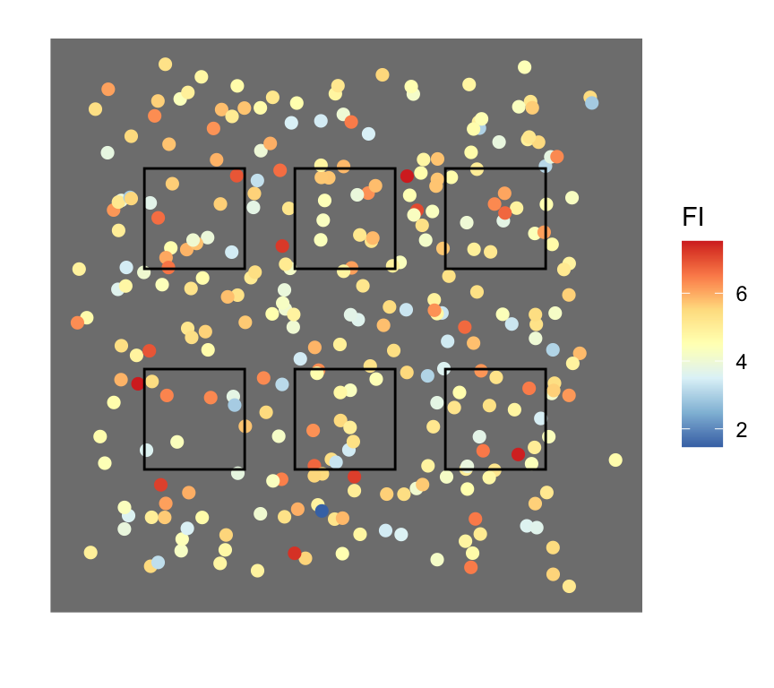

- For any random sample, the sample mean almost certainly doesn’t equal the true mean of the population due to **sampling error**.

## Sampling distribution

- Let’s sample our biological process multiple times (e.g. by recording multiple FOVs) but at different magnifications such that we have a different number of cells per FOV.
- From each sample (=FOV) we calculate a sample mean FI.
- In both cases the total number of cells is the same!
- Red dashed line is the *population mean*.

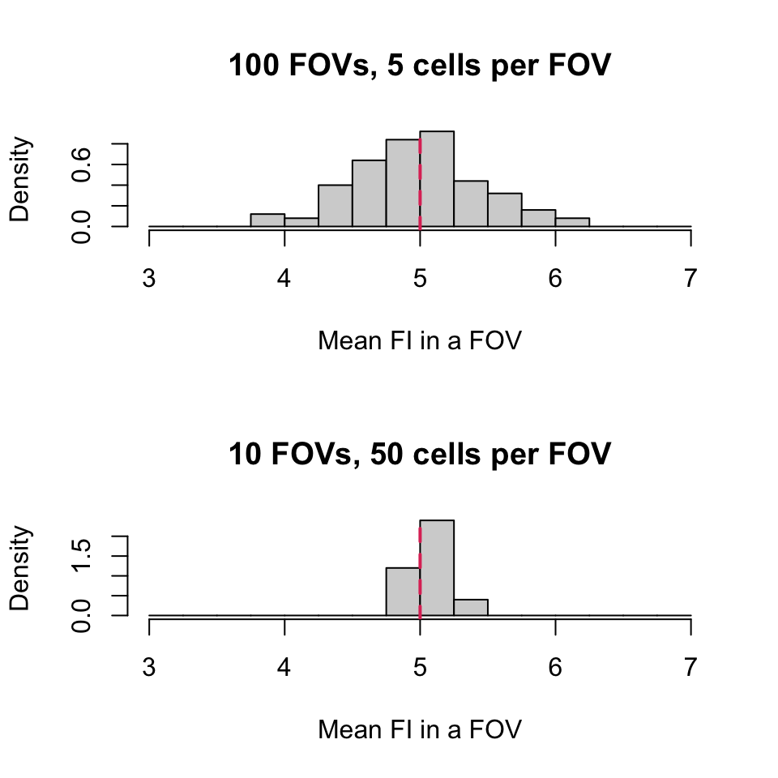

## Sampling distribution II

- A **sampling distribution** is the distribution of a statistic, such as the **mean**, that is obtained by repeatedly drawing a large number of samples from a specific population.
- This distribution allows you to determine the probability of obtaining the **sample statistic**.

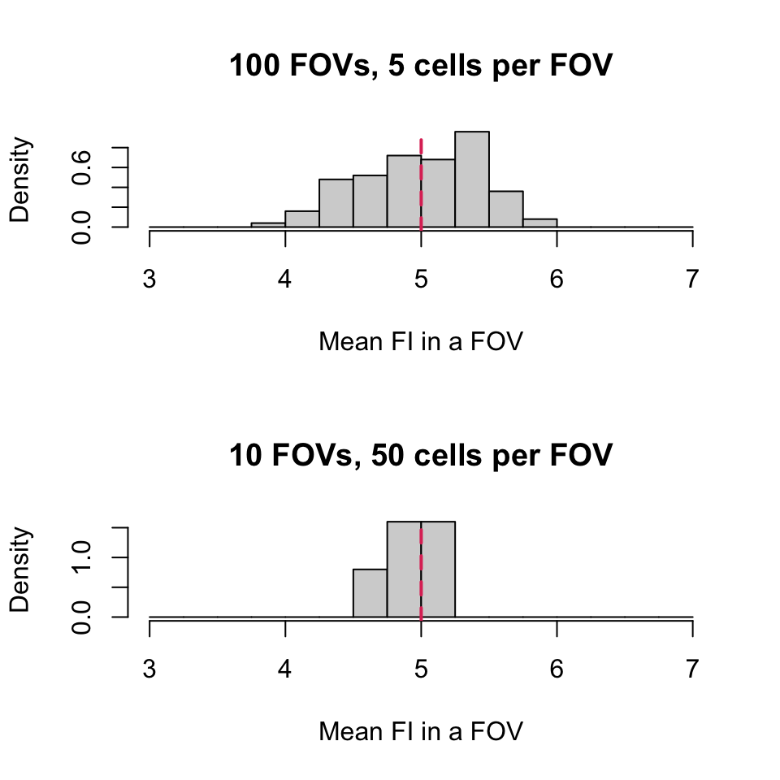

## Sampling distribution III

- Fortunately, we can create a plot of the distribution of sample means without collecting many different random samples!
- Instead, we’ll create a probability distribution plot using the t-distribution.

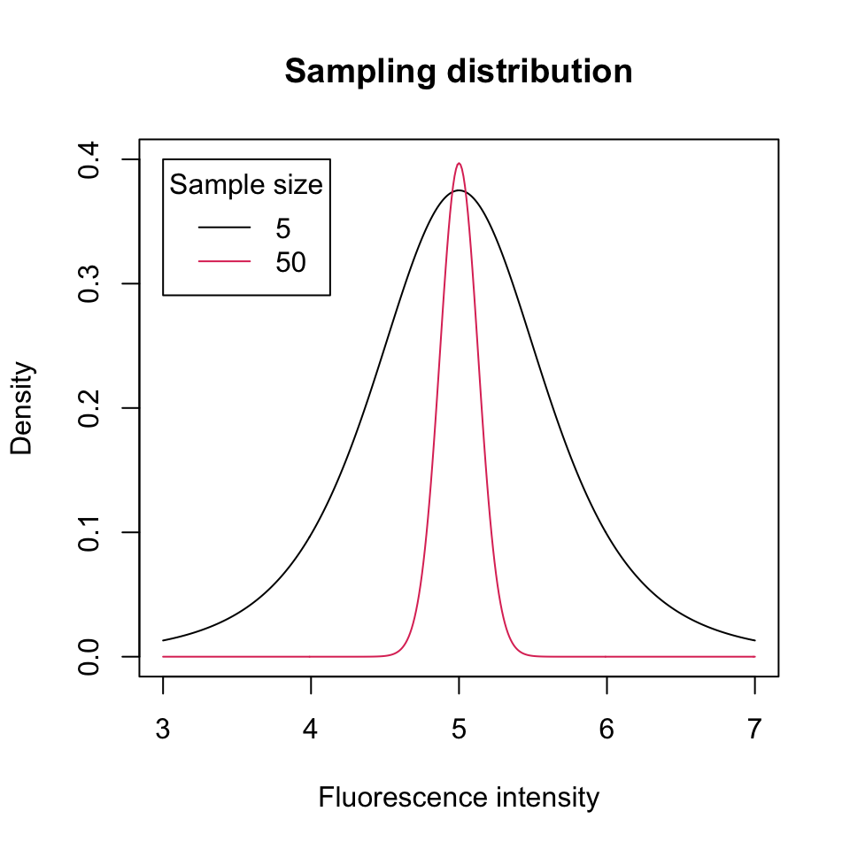

## Student’s t-distribution

- A normal distribution describes a full population. T-distributions describe samples drawn from a full population.
- The t-distribution differs for each sample size. The larger the sample, the more it resembles a normal distribution.
- \[ t = \frac{\bar{x} - \mu}{s / \sqrt{n}} \]
- Where, \(\bar{x}\) is the mean, \(s\) standard deviation, \(n\) size of the **sample**. \(\mu\) is the expected mean of the **population**.

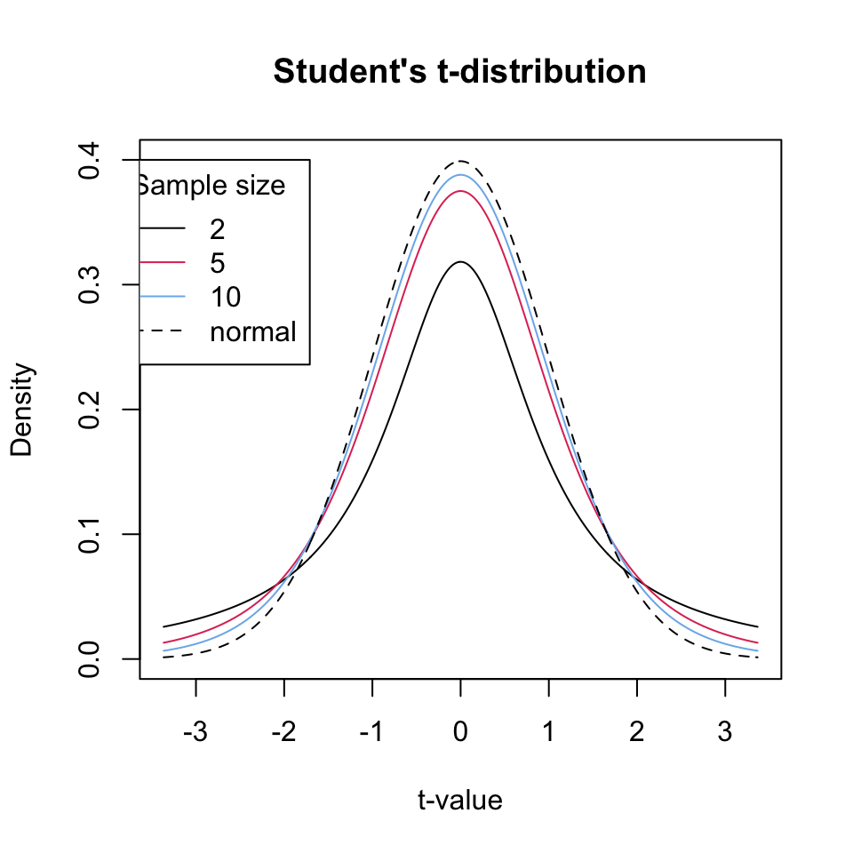

## Statistical significance

## Significant difference

- Let’s move to another well. This time we measured the FI of 5 cells, which yielded the mean 6.5.
- Is the new sample mean *significantly different* from the population mean?
- There is no magic place on the distribution to determine *significant difference*.
- We have a continuous decrease in the probability of obtaining sample means that are farther from the population mean.
- Where to draw the line?

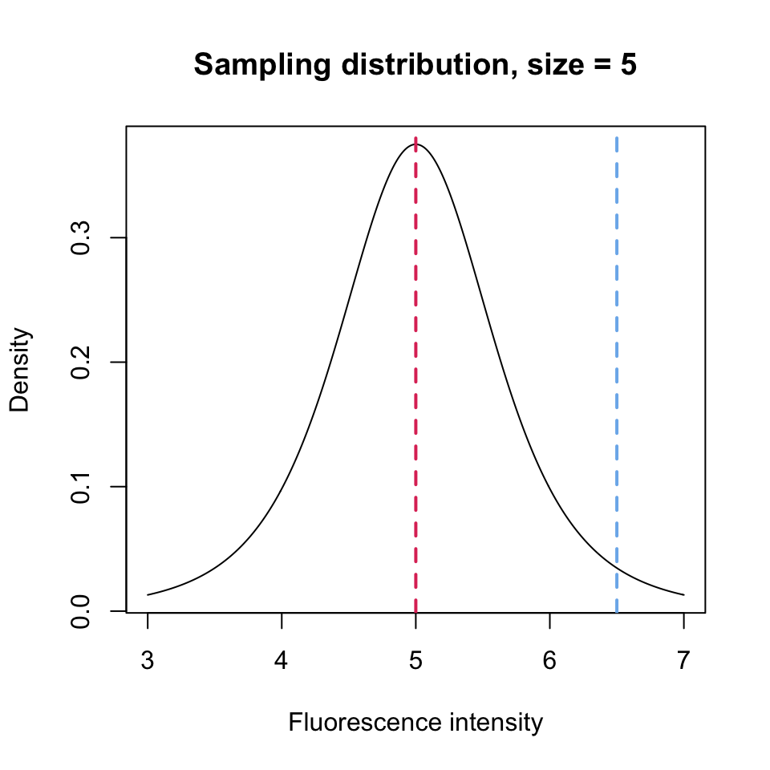

## Threshold for unusuality

- If our threshold for *unusuality* is 10 or 5%, then the new sample mean (=6.5) IS unusual.
- If our threshold for *unusuality* is 1%, then the new sample mean (=6.5) IS NOT unusual.

## Hypothesis testing

## Formulate hypotheses

This new measurement *seems* quite different from the **population** mean (=5).

- Is it still the same treatment?
- What are the chances of obtaining the **sample** mean (=6.5) given the **population** mean (=5)?
- Let’s formulate hypotheses!
- Null hypothesis: the population mean equals the hypothesised mean (=5)
- Alternative hypothesis: the population mean differs from the hypothesized mean (=5)
- By setting a threshold for *unusuality* we can reject (or not) the null hypothesis.

## Significance level

- These thresholds are the **significance levels**, \(\alpha\).
- It is the probability of rejecting the null hypothesis when it is true.
- It’s a **risk** of concluding that a difference exists when there is no actual difference.

## P-value

- We’ve tested the null hypothesis by looking at the *location* of our sample mean with respect to chosen *significance levels*.
- How to determine the statistical significance at a chosen level without looking at the graph?
- Let’s shade the probability of obtaining our sample mean (=6.5) that is **at least as extreme** in both tails of the distribution (\(5 \pm 1.5\)).

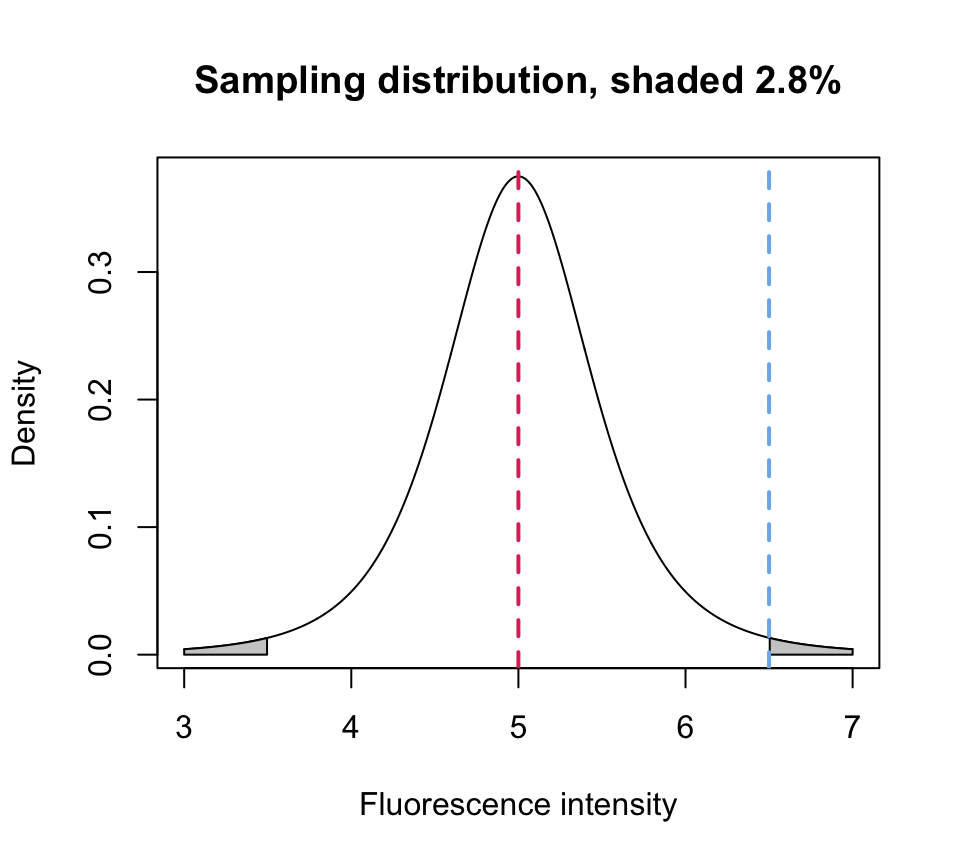

## P-value II

- This shaded probability represents the likelihood of obtaining a sample mean that is **at least as extreme as** our sample mean (=6.5) in both tails of the distribution if the population mean is 5.
- That’s our P value!
- When a P value is less than or equal to the chosen significance level, we **reject the null hypothesis**.

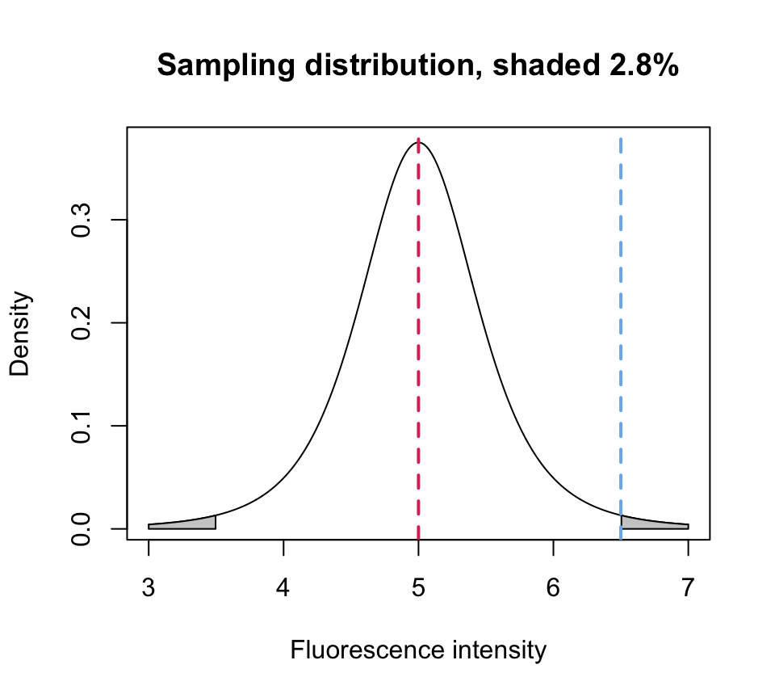

## Confidence intervals

## Estimate population mean

- Let’s try to estimate the population mean.
- We sample once by measuring 5 cells.

- | Sample |
  | --- |
  | 4.273791 |
  | 5.064480 |
  | 3.419903 |
  | 3.749903 |
  | 5.079963 |

- Sample mean = 4.317608
- Sample SD = 0.753174

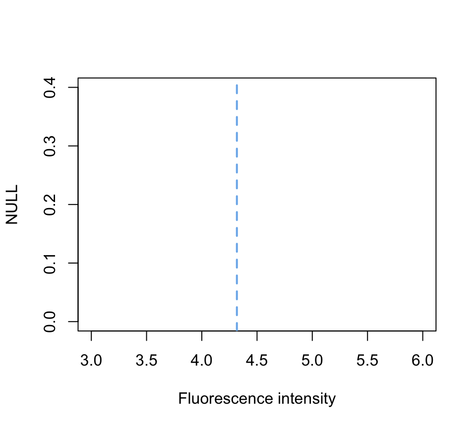

## Point estimate

- The **sample** mean is the most likely value for the **population** mean given the **information we have**.
- It is a **point estimate**, or a *best guess*, of an unknown population mean.
- However, it would not be unusual to obtain different sample means if we drew other random samples from the same population.

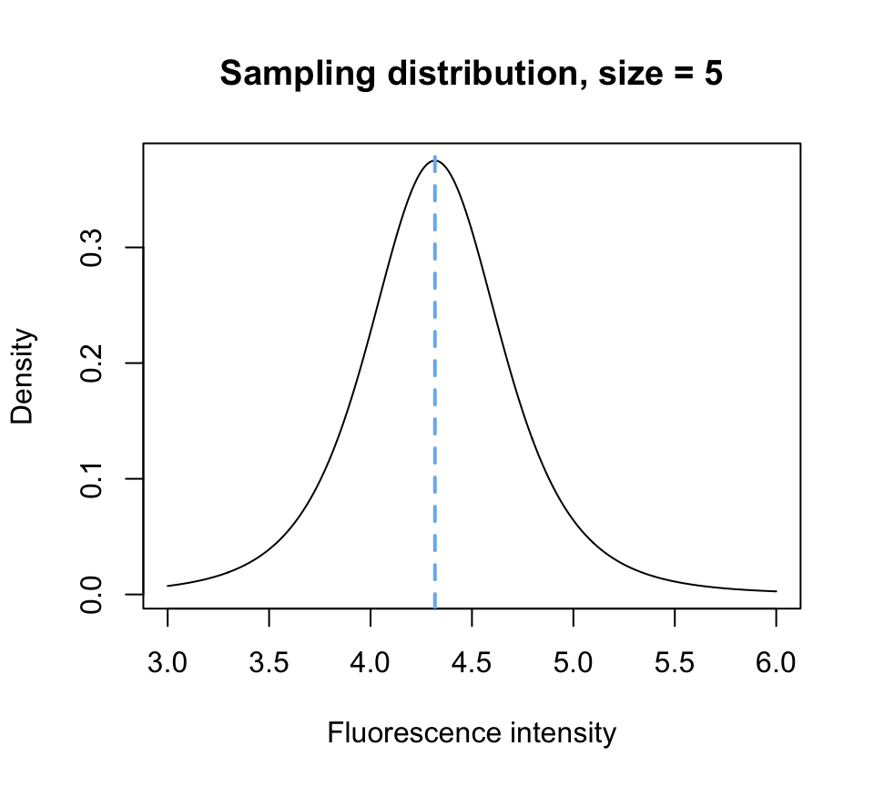

## Margin of error

- To put a number on this, let’s shade the inner 95% of the distribution.
- 95% is an arbitrary but a commonly accepted typical range.
- A specific CI represents the **margin of error**, or the amount of uncertainty, around the point estimate, which is our single sample mean.
- A confidence **interval** is a range of values that is likely to contain an unknown population parameter.
- It is NOT the probability of the **population** mean being in THAT range!
- The population mean is UNKNOWN and we cannot place it on this graph.

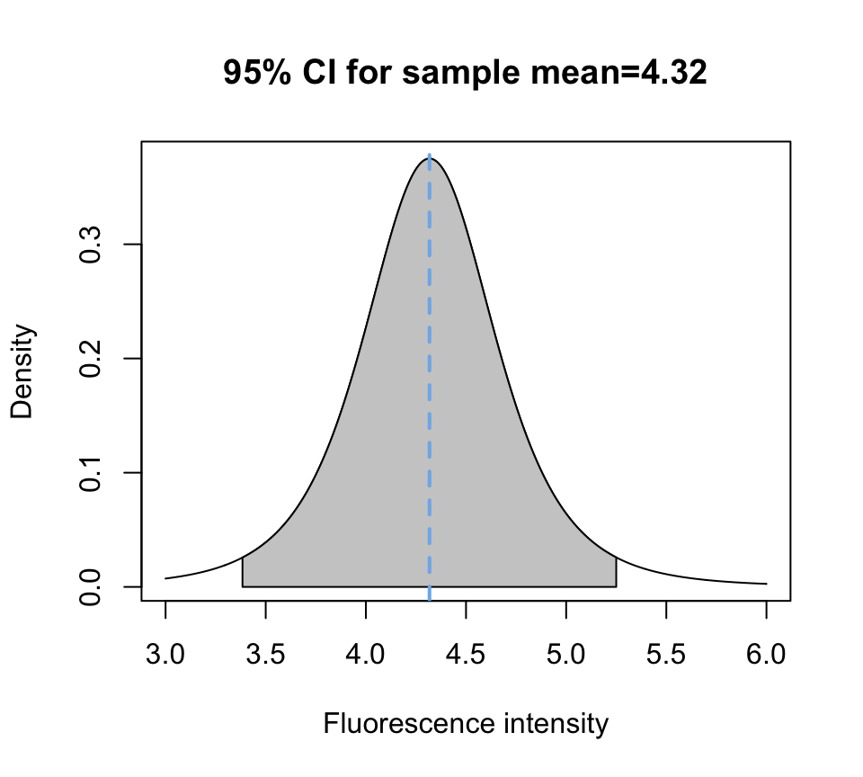

## CI in hypothesis testing

- If you draw a random sample many times (from the same population!), a certain percentage of confidence intervals will contain the population mean.
- This percentage is the **confidence level**!
- In our case 95% of the time, the confidence interval WILL contain the population mean.

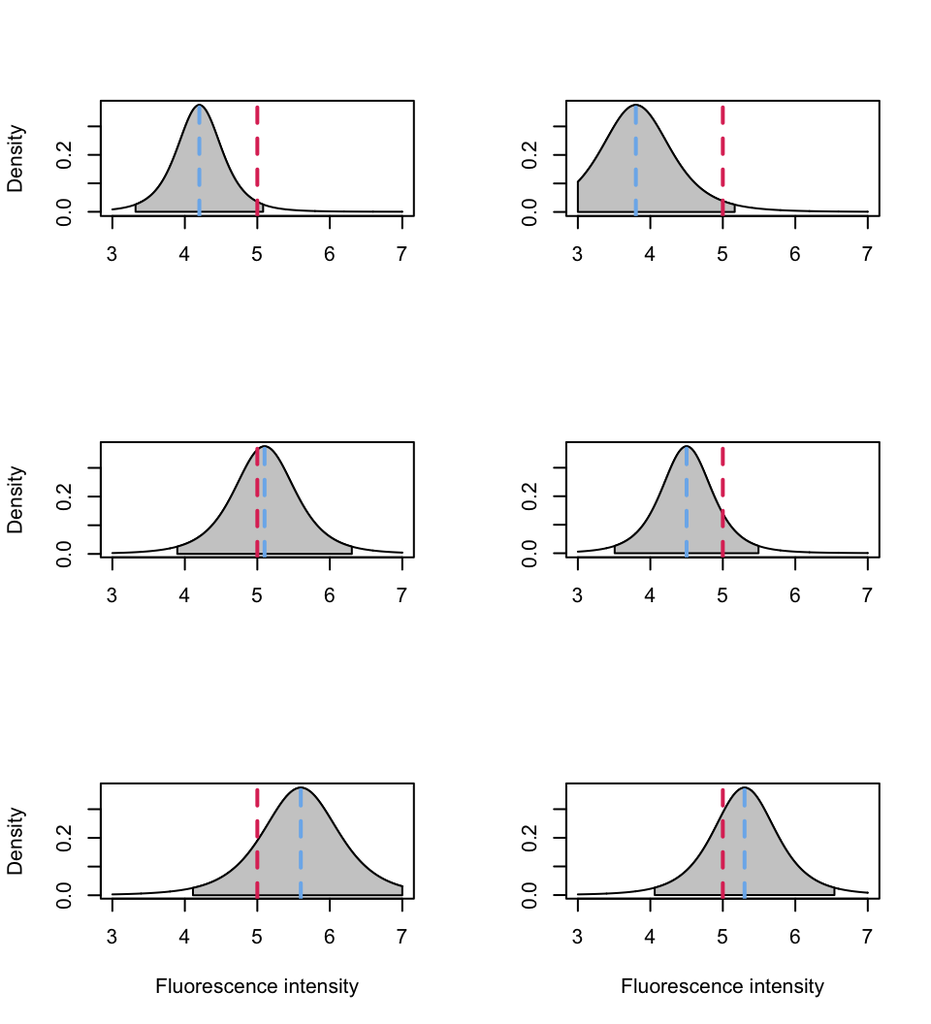

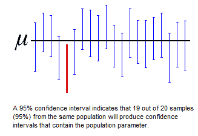

## Example of CI

From [Khan Academy](https://www.khanacademy.org/math/ap-statistics/estimating-confidence-ap/introduction-confidence-intervals/a/interpreting-confidence-levels-and-confidence-intervals):

> A baseball coach was curious about the true mean speed of fastball pitches in his league. The coach recorded the speed in kilometers per hour of each fastball in a random sample of 100 pitches and constructed a 95%, percent confidence interval for the mean speed. The resulting interval was (110,120).

Correct statement:

We’re 95% **confident** that the interval (110,120) captured the true mean pitch speed.

Incorrect statement:

- There is a 95% **chance** that the true mean is within the (110, 120) interval.
- About 95% of pitches in the sample were between 110 and 120.
- If the coach took another sample of 100 pitches, there’s a 95% chance the sample mean would be between 110 and 120.

## P values vs CI

- You can use either P values or confidence intervals to determine whether your results are statistically significant.
- If a hypothesis test produces both, these results will agree.
- The confidence level is equivalent to \(1 - \alpha\)-level.
- If the P value is less than your significance level (\(\alpha\)), the hypothesis test is statistically significant.
- If the confidence interval does not contain the null hypothesis value, the results are statistically significant.
- If the P value is less than \(\alpha\), the confidence interval will not contain the null hypothesis value.

## P values vs CI II

The **significance level** defines the distance the sample mean must be from the null hypothesis to be considered statistically significant.

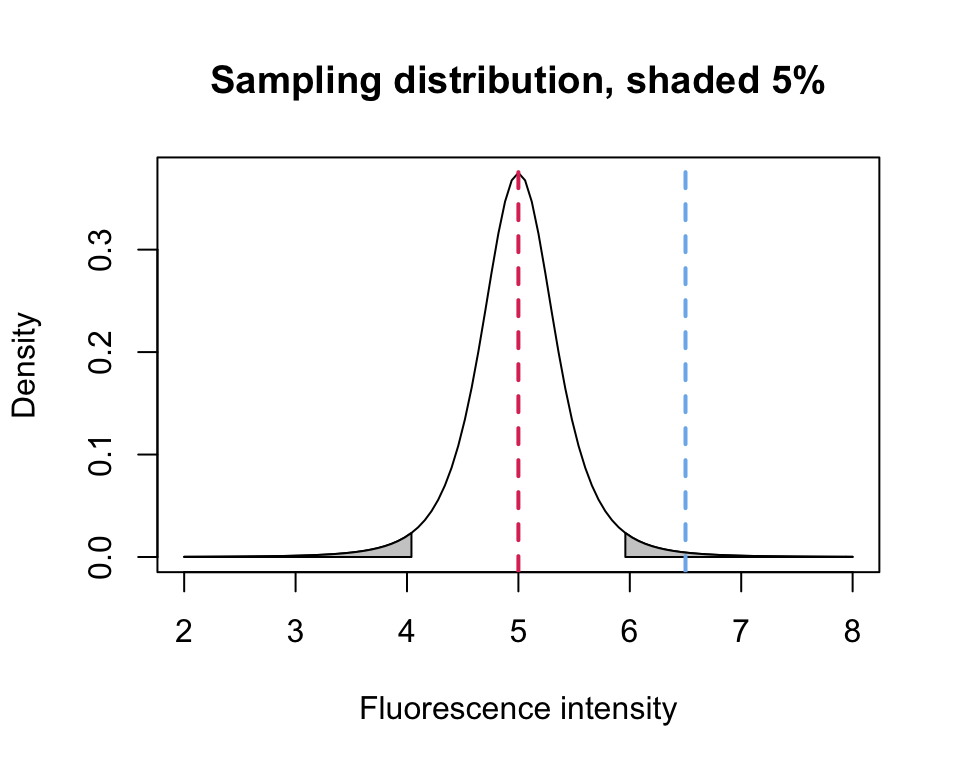

The **confidence level** represents the percentage of intervals that would include the population parameter if you took samples from the same population again and again.

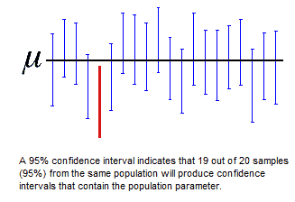

## Type of errors

[What are type I and type II errors?](https://support.minitab.com/en-us/minitab/19/help-and-how-to/statistics/basic-statistics/supporting-topics/basics/type-i-and-type-ii-error/)

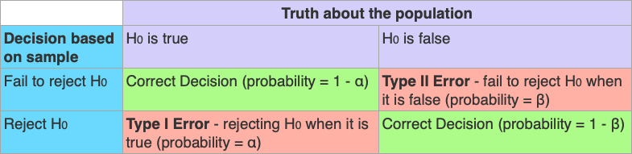

## Pitfalls

- The P-value is not a “score”.
- The P-value is NOT the probability that the null hypothesis is true.
- It is the probability of obtaining an effect at least as extreme as the one in your sample data, assuming that the null hypothesis is true.
- The confidence level is NOT the probability that a specific CI contains the population parameter.
- It is a range of values that is likely to contain an **unknown population parameter**.
- If you draw a random sample many times, a certain percentage of CIs will contain the population parameter.
- This percentage is the [confidence level](https://www.khanacademy.org/math/ap-statistics/estimating-confidence-ap/introduction-confidence-intervals/v/confidence-intervals-and-margin-of-error).